# HW1

First, we need to generate a spline of the data, and remove the points that don't exist from the table. I will be using the Gibbs convention.

```python
%matplotlib inline
import scipy.interpolate as sci
import scipy.optimize as sco
import scipy.constants as c
import numpy as np
from mpl_toolkits.mplot3d import Axes3D
```

```python
x = np.nan
gamma = np.array([[73.7,72.5,71.2,68.4,65.3,62.2,59.0],
                  [71.0,69.5,68.1,65.8,63.4,60.5,57.4],
                  [65.0,64.3,63.5,62.2,40.4,58.2,55.5],
                  [62.0,59.9,58.6,56.8,55.2,53.9,52.3],
                  [52.2,51.1,50.3,48.8,47.5,46.6,46.0],
                  [45.9,44.0,42.4,40.9,40.0,39.5,39.2],
                  [35.9,34.8,33.8,32.5,31.4,31.1,31.0],
                  [28.2,x   ,26.6,x   ,23.2,21.4,19.7]],np.float64)

#Data for this problem set was taken from Vargaftik, Volkov and Voljack, International tables
#of the surface tension of water,
#Journal of Physical Chemistry Reference Data, Vol 12, No 3. 1983
#www.nist.gov/data/PDFfiles/jpcrd231.pdf
surfaceTensionH2O = np.array([75.64,74.95,74.23,73.5,72.75,71.99,71.20,70.41,69.6,68.78,67.94,67.1,66.24,65.36,64.47,63.58,62.67,61.75,60.82,59.87,58.91])
TsforST = np.arange(0.,101,5)
TsforST[0]=0.01
stH2O = sci.interp1d(TsforST,surfaceTensionH2O)


conc = np.array([0.007,0.021,0.050,0.104,0.246,0.489,1.006,11.04],np.float64)
T = np.array([0,10,20,40,60,80,100])
molNumUnits = "millimole/m^2"
weights = np.ones(gamma.shape)
mask = np.isnan(gamma)
weights[mask]=0
#gamma[mask]=20
```

Now, we need a relation between $\gamma$ and everything else. We know that $\renewcommand{\d}[0]{\mathrm{d}}$ $$\left|\frac{\mathrm{d}\gamma}{\mathrm{d}T}\right|_{\mu} = -\bar{S}$$ $$\left|\frac{\mathrm{d}\gamma}{\mathrm{d}\mu}\right|_{T} = -\Gamma$$ with these two relations, we need only to relate concentration to chemical potential.

$$\mu = \mu^{\circ} + RT\ln{(a)}$$ $$a(C) = \alpha C$$

We will assume that the concentration is small enough for $\alpha = 1$ in order to make this problem tractable. $$\therefore a(C) = C\Rightarrow\mu = \mu^{\circ} + RT\ln{(C)}$$ and $$\d\mu = R\ln{(C)} \d T + \frac{RT}{C} \d C$$ Limiting ourselves to isotherms eliminates the first term in the equation, while constant concentration eliminates the second

```python
T2 = np.tile(T,(np.size(conc),1))[~mask].ravel()
c2 = np.tile(conc,(np.size(T),1)).T[~mask].ravel()
g2 = gamma[~mask].ravel()
mu2 = c.R*c.C2K(T2) *np.log(c2)
weights = weights[~mask]
gammaF=sci.bisplrep(c.C2K(T2),mu2,g2,w=weights.ravel(),quiet=1)
def gF(x,y,g=gammaF,dx=0,dy=0):
    return sci.bisplev(c.C2K(x),y,gammaF,dx=dx,dy=dy)
```

```python
Sbar = - gF(20,c.R*293*np.log(0.05),dx=1)
Gamma = - gF(20,c.R*293*np.log(0.05),dy=1)
print("Excess Entropy","= {:.2f} mN/(m K)\r\nExcess Mole Number= {:.2e} {}".format(Sbar,Gamma,molNumUnits))
def myFunc(x):
    return gF(20,x,dy=1)
num = sco.minimize(myFunc,-300,method='Powell')
```

```
Excess Entropy = 0.27 mN/(m K)
Excess Mole Number= 2.47e-03 millimole/m^2
```

b) Discuss the meaning of the number for $\Gamma$ computed in (a) in terms of molecular distribution functions (density of n-butyric acid with z) as might be determined by an MD Simulation. Calculate a reasonable $\Gamma_\mathrm{Max}$ for $T=20^\circ C$

$\Gamma$ is the excess surface energy per change in chemical potential of the system. $$\left|\frac{\mathrm{d}\gamma}{\mathrm{d}\mu}\right|_{T} = -\Gamma$$ so an increase in the concentration at the surface will tend to reduce surface energy, which means that it is energetically favorable for the system to concentrate n-butyric acid at the surface. this means that the interface would be lined with n-butyric acid.

```python
print("The maximum excess mole number is {:.2e} {} at 293 Kelvin".format(-myFunc(num.x.item()),molNumUnits))
```

```
The maximum excess mole number is 4.79e-03 millimole/m^2 at 293 Kelvin
```

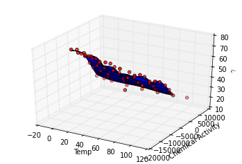

```python
Ts = np.linspace(0,100)
concs = np.linspace(0.007,1)
mus = c.R*c.C2K(Ts)*np.log(concs)
X,Y = np.meshgrid(Ts,mus)
zs = np.array([gF(Ts,mus) for Ts,mus in zip(np.ravel(X),np.ravel(Y))])
Z = zs.reshape(X.shape)
fig = plt.figure()
ax = fig.add_subplot(111,projection='3d')
ax.plot_surface(X,Y,Z)
ax.scatter(T2,mu2,g2,c='red')
ax.set_xlabel('Temp')
ax.set_ylabel('Chemical Activity')
ax.set_zlabel('$\gamma$')
```

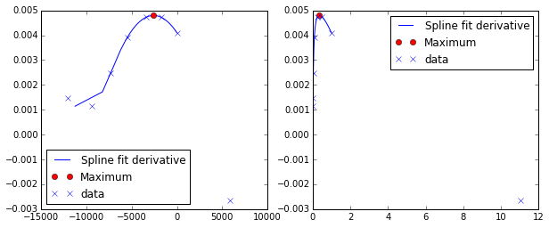

```python
fig=plt.figure(figsize=(10,4))
fig.add_subplot(121)
plt.plot(mus,-gF(20,mus,dy=1),label='Spline fit derivative')
if num.success:
    plt.plot(num.x,-gF(20,num.x,dy=1),'ro',label='Maximum')
    plt.plot(c.R*c.C2K(20)*np.log(conc),-gF(20,c.R*c.C2K(20)*np.log(conc),dy=1),'bx',label='data')
    plt.legend(loc="best")
fig.add_subplot(122)
plt.plot(concs,-gF(20,mus,dy=1),label='Spline fit derivative')
if num.success:
    plt.plot(np.exp(num.x/(c.R*c.C2K(20))),-gF(20,num.x,dy=1),'ro',label='Maximum')
    plt.plot(conc,-gF(20,c.R*c.C2K(20)*np.log(conc),dy=1),'bx',label='data')
    plt.legend(loc="best")
```

The limitations of the Langmuir isotherm include that it cannot accurately predict behavior around the critical micellar concentration, or above that concentration. It also cannot predict when the excess mol number will be negative, which can happen in reality.

```python
def excessEntropy(T,conc):
    mu = c.R*c.C2K(T)*np.log(conc)
    return -gF(T,mu,dx=1)
def excessMolNum(T,conc):
    mu = c.R*c.C2K(T)*np.log(conc)
    return -gF(T,mu,dx=1)
def excessChemicalPotential(T,conc):
    return c.R*c.C2K(T)*np.log(conc)
def excessEnthalpy(T,conc):
    mu = c.R*c.C2K(T)*np.log(conc)
    return gF(T,mu)- T * gF(T,mu,dx=1)
```

$$\frac{\pi}{kT\Gamma} = 1 + B\Gamma + C\Gamma^2 +\ldots$$ $$\frac{\pi}{kT} = \Gamma + B\Gamma^2 + C\Gamma^3 +\ldots$$

In order to do a least-squares regression, we define the sum of squares function $S$

$$S(B,C,\ldots) = \sum_{i=1}^N (e_i)^2 = \sum_{i=1}^N (\frac{\pi_i}{kT} - \Gamma_i - B\Gamma_i^2 - C\Gamma_i^3 - \ldots)^2$$ $$\frac{\partial S}{\partial B} = \sum_{i=1}^N 2(\frac{\pi_i}{kT} - \Gamma_i - B\Gamma_i^2 - C\Gamma_i^3 - \ldots)(-\Gamma^2)=0$$ $$\frac{\partial S}{\partial C} = \sum_{i=1}^N 2(\frac{\pi_i}{kT} - \Gamma_i - B\Gamma_i^2 - C\Gamma_i^3 - \ldots)(-\Gamma^3)=0$$ And so forth. This can be rewritten in the form: $$\sum_{i=1}^N \frac{\pi_i}{kT} = \sum_{i=1}^N \Gamma_i^2 + \sum_{i=1}^N B\Gamma_i^3 + \sum_{i=1}^N C\Gamma_i^4 + \ldots $$ $$\sum_{i=1}^N \frac{\pi_i}{kT} = \sum_{i=1}^N \Gamma_i^3 + \sum_{i=1}^N B\Gamma_i^4 + \sum_{i=1}^N C\Gamma_i^5 + \ldots $$ Or in matrix form: $$Y = Ax$$ $$Y = \begin{pmatrix} \sum_{i=1}^N \frac{\pi_i}{kT}\Gamma_i^2\\ \sum_{i=1}^N \frac{\pi_i}{kT}\Gamma_i^3\\ \sum_{i=1}^N \frac{\pi_i}{kT}\Gamma_i^4\\ \ldots\end{pmatrix}$$ $$A = \begin{pmatrix}B \\ C \\ D \\ \ldots\end{pmatrix}$$ $$x = \begin{pmatrix}\sum_{i=1}^N \Gamma_i^2 & \sum_{i=1}^N\Gamma_i^3 & \sum_{i=1}^N\Gamma_i^4 & \ldots\end{pmatrix}$$

I will also assume a langmuir isotherm $$\Gamma = \frac{b C \Gamma_\mathrm{max}}{1 + b C}$$

```python
def y(Temp,deg=2):
    if(Temp in T):
        c2 = np.array([0.007,0.021,0.050,0.104,0.246,0.489,1.006,11.04],np.float64)
        gF2 = sci.interp1d(c2,gamma[:,np.argwhere(T==Temp)].ravel(),kind='linear')
        yOut = np.zeros(deg)
        for n in range(deg):
            Gamma = -gF(Temp,c.R*c.C2K(Temp)*np.log(c2),dy=1)
            yOut[n] = np.sum((stH2O(Temp) - gamma[:,np.argwhere(T==Temp)].ravel())\
                               /(c.k*c.C2K(Temp))*(Gamma**(n+2)))
        return yOut
    else:
        return conc*0
def x(Temp,deg=2):
    c2 = np.array([0.007,0.021,0.050,0.104,0.246,0.489,1.006,11.04],np.float64)
    if(Temp in T):
        aOut = np.zeros((deg,deg))
        Gamma = -gF(Temp,c.R*c.C2K(Temp)*np.log(c2),dy=1)
        for n in range(deg):
            for m in range(deg):
                aOut[n] = np.sum(Gamma**(n+m+2))
        return aOut
    else:
        return 0
Gamma = -gF(20,c.R*c.C2K(20)*np.log(np.array([0.007,0.021,0.050,0.104,0.246,0.489,1.006,11.04],np.float64)),dy=1)
```

[output not shown]